# Étude de la distribution de la distance entre vecteurs de RTF : cas dynamique

## Motivation

La méthode de localisation RTF-MFP nécessite de définir une grandeur scalaire caractéristique de la distance entre vecteurs de RTFs.

En pratique les RTFs sont estimés à un nombre K de bins fréquentiels donné et on doit donc évaluer la distance entre les deux ensembles de RTF(k) (c'est mal dit en language math mais on se comprend).

L'approche la plus simple utilisée jusque ici consiste à utiliser l'angle hermitien comme métrique caractéristique de la distance entre deux vecteurs de RTF(k) et de considéré l'angle hermitien moyen sur l'ensemble des bins fréquentiels :

$$ \overline{\theta} (\Pi, \hat{\Pi}) = \frac{1}{K} \sum_{k=0}^{K-1} arccos(\frac{\lvert \Pi^H(k)\hat{\Pi}(k) \rvert }{\lVert \Pi^H(k) \rVert \lVert \hat{\Pi}(k) \rVert }) $$

Implicitement on suppose donc que la distribution des angles $\theta(k)$ est gaussienne et que donc la moyenne empirique est caractéristique de cette distribution. Néanmoins, dans le cas où la distribution s'écarte largement d'une distribution gaussienne la moyenne empirique n'est plus représentative de cette distribution et il est nécessaire de considérer une autre grandeur caractéristique.

L'objectif de ce notebook est d'analyser la distribution des $\theta(k)$ afin de valider ou d'invalider l'hypothèse gaussienne. Dans le cas où la distribution n'est pas gaussienne il s'agira d'étudier la possibilité d'associer la distribution des $\theta(k)$ à une forme de distribution statistique connue et d'en calculer les paramètres caractéristiques.

## Démarche

Ici on s'intéresse à la distance entre vecteurs de RTF estimés par les méthodes CS et CS-EVD pour la source en mouvement et vecteurs de RTF associés calculer par déconvolution pour les enregistrements statiques.

## Références

```python
import sys
sys.path.append(r"C:\Users\baptiste.menetrier\Desktop\devPy\phd")

from misc import progression_bar
from propa.rtf.rtf_utils import D_hermitian_angle_fast
from real_data_analysis.fiberscope_20.src import params
from real_data_analysis.fiberscope_20.src.fiberscope_manager import FiberscopeManager
from real_data_analysis.fiberscope_20.src.fiberscope_recording import (
    FiberscopeSweep1,
    FiberscopeDynamicRecording,
)
from real_data_analysis.fiberscope_20.src.etude_perf.distance_distribution_utils import *
```

# Étape 1 : définition des paramètres de l'étude

## Paramètres généraux

```python
# Reference hydrophone
h_index_ref = 5  # H5 (assumed to be the receiver with the largest SNR)

rtf_estimators = ["cs", "cs-evd"]

# Static recordings to use
fs_sweep = FiberscopeSweep1()
static_records = fs_sweep.records_N1

# Usefull path
root_data = os.path.join(params.root_data, "etude_perf", "distance_distribution")
root_img = os.path.join(params.root_img, "etude_perf", "distance_distribution")

# Folder to store output datasets
root_results = os.path.join(root_data, "results")
root_static_ref = os.path.join(root_data, "static")
root_dynamic = os.path.join(root_data, "dynamic")

sliced_data_folder = os.path.join(
    params.root_data, "etude_perf", "duration_influence", "results", "sliced_data"
)

roots = (
    [
        root_data,
        root_img,
        root_results,
        root_static_ref,
        root_dynamic,
        sliced_data_folder,
    ]
)
for root in roots:
    if not os.path.exists(root):
        os.makedirs(root)

# File paths to pre-processed results
fpath_theta = os.path.join(root_results, "theta_pos_dynamic.csv")
fpath_frobenius = os.path.join(root_results, "d_frobenius_pos_dynamic.csv")
fpath_frobenius_mod = os.path.join(root_results, "d_frobenius_mod_dynamic.csv")

# Signal repetition period
Tr = fs_sweep.interp_pulse_period
# Number of LFM emitted
n_lfm = fs_sweep.n_sweep

# Window lengths to test
nw_min = 1
Tw_min = nw_min * Tr  # Minimum duration to consider
Tw = np.array([Tw_min + nwi * Tr for nwi in range(nw_min, n_lfm)])
n_win = len(Tw)
```

```python
dist_func = D_hermitian_angle_fast
ax_f = 1
ax_rcv = 0
dist_kwargs = {
    "ax_f": ax_f,
    "unit": "deg",
    "ax_rcv": ax_rcv,
    "apply_mean": False,
    "apply_median": False,
}
```

```python
# Define the order based on the source position : from closest to farthest
dict_th_pos = params.dict_th_pos
all_dists = np.array([dict_th_pos[pos] for pos in dict_th_pos.keys()])
idx_pos_sort = np.argsort(all_dists)
src_labels = list(dict_th_pos.keys())
src_label_sorted = [src_labels[i] for i in idx_pos_sort]
all_dists_sorted = all_dists[idx_pos_sort]
```

## Paramètres de calcul des STFT

Les paramètres ci-dessous sont les paramètres optimaux calculés pour un signal d'une durée de 2 s.

```python
# Save optimum properties
opti_stft_props = {
    "n_stft": {
        "cs": 2**15,
        "cs-evd": 2**15,
    },
    "alpha_ov": {
        "cs": 0.75,
        "cs-evd": 0.75,
    },
}
```

## Flags

```python
run_distance_computation = False
run_rtf_computation = False
```

# Calcul des RTFs pour chacun des segments du signal dynamique

```python
rtf_e = "cs-evd"
fs_dynamic = FiberscopeDynamicRecording()

# Choix du pas de temps pour le découpage du signal c'est important
time_step = 3  # s
n_sweep_step = int(time_step / fs_dynamic.signal.interp_pulse_period)

# Create an instance of FiberscopeManager
fsm = FiberscopeManager(
    root_processed_data=root_dynamic,
    h_index_ref=h_index_ref,
    plot_feature=False,
)

# Set STFT params
fs_sweep1 = FiberscopeSweep1()
fs_sweep1.records_folder = root_static_ref

fsm.nperseg = opti_stft_props["n_stft"][rtf_e]
fsm.noverlap = int(opti_stft_props["alpha_ov"][rtf_e] * fsm.nperseg)
print(f"(nperseg = 2**{int(np.log2(fsm.nperseg))}, nov = {fsm.noverlap})")

if run_rtf_computation:
    fsm.process_static_analysis(
        static_signal=fs_sweep1,
        static_records_names=fs_sweep1.records_N1,
        set_stft_props=False,
        rtf_estimator=rtf_e,
    )

# Load pre-saved data
data = xr.load_dataset(
    os.path.join(
        r"C:\Users\baptiste.menetrier\Desktop\devPy\phd\real_data_analysis\fiberscope_20\data\dynamic",
        f"{fs_dynamic.recording_name}.nc",
    )
)
# preSplit the dynamic recording
fsm.presplit_dynamic_record(
    fs_dynamic_recording=fs_dynamic,
    n_sweep=n_sweep_step,
    t_max=np.max(data.time.values),
)

if run_rtf_computation:

    # Split dynamic records and save as nc
    fsm.split_dynamic_record(fs_dynamic_recording=fs_dynamic, force_reload=False)

    # Derive features
    fsm.process_dyn_analysis(
        fs_dynamic_recording=fs_dynamic,
        use_global_noise_csdm=False,
        set_stft_props=False,
        rtf_estimator=rtf_e,
    )
```

```
(nperseg = 2**15, nov = 24576)
```

# Étape 2 : chargement des données correspondant à chacun des segments du signal de la source dynamique

```python
# Load pre-computed datasets
dynamic_records = fs_dynamic.splitted_records_names
rtf_estimators = [rtf_e]    # No need to check for both
results = {rtf_e: {recording_name: None for recording_name in dynamic_records} for rtf_e in rtf_estimators}
for rtf_e in rtf_estimators:
    for recording_name in dynamic_records:
        xr_snapshot= xr.open_dataset(
            os.path.join(
                fs_dynamic.splitted_records_folder,
                f"{recording_name}_rtf.nc"
            )
        )
        results[rtf_e][recording_name] = xr_snapshot
```

# Étape 3 : Calcul de la distance pour chaque position statique

On calcule les distances d'intérêt pour chacune des positions de référence et chacun des segments du signal dynamique et on étudie le comportement des distributions obtenues.

```python
# Compute theta for each slice
fmin = fs_sweep.fmin
fmax = fs_sweep.fmax
# fmin = 11900
# fmax = 12000

if run_distance_computation:
    thetas = {rtf_e: {rec: [] for rec in static_records} for rtf_e in rtf_estimators}
    d_frobenius_mod = {
        rtf_e: {rec: [] for rec in static_records} for rtf_e in rtf_estimators
    }
    d_frobenius = {rtf_e: {rec: [] for rec in static_records} for rtf_e in rtf_estimators}

    # Progress bar
    index = 0
    prev_progress = 0
    n_iter = len(rtf_estimators) * len(static_records) * len(dynamic_records)

    for rtf_e in rtf_estimators:

        # Iterate over recordings
        for static_recording_name in static_records:
            # Load static recording
            ds_rtf_static = xr.open_dataset(
                os.path.join(root_static_ref, f"{static_recording_name}_rtf.nc")
            )
            # Extract RTF ref (from deconvolution)
            rtf_ref_mod_static = ds_rtf_static.rtf_amp
            rtf_ref_phase_static = ds_rtf_static.rtf_phase

            for recording_name in dynamic_records:

                prev_progress = progression_bar(index=index, index0=0, indexf=n_iter-1, prev_progress=prev_progress)
                index += 1

                ds_rtf = results[rtf_e][recording_name]

                # Select frequency band
                ds_rtf = ds_rtf.sel(f_ir=slice(fmin, fmax))
                ds_rtf = ds_rtf.sel(f_rtf=slice(fmin, fmax))

                # Extract RTF hat (from CS-EVD)
                rtf_hat_mod = ds_rtf.rtf_amp_hat
                rtf_hat_phase = ds_rtf.rtf_phase_hat

                # Interp RTF ref at RTF hat frequencies (nearest neigbor)
                rtf_ref_mod = rtf_ref_mod_static.sel(
                    f_ir=rtf_hat_mod.f_rtf.values, method="nearest"
                )
                rtf_ref_phase = rtf_ref_phase_static.sel(
                    f_ir=rtf_hat_mod.f_rtf.values, method="nearest"
                )

                # Build rtfs
                rtf_ref = rtf_ref_mod * np.exp(1j*rtf_ref_phase)
                rtf_hat = rtf_hat_mod * np.exp(1j*rtf_hat_phase)

                # Compute mean theta distance over the frequency band of interest
                theta = dist_func(rtf_ref=rtf_ref.values, rtf=rtf_hat.values, **dist_kwargs)
                thetas[rtf_e][static_recording_name].append(theta)

                # Compute squarred frobenius distance
                delta_pi = rtf_ref.values - rtf_hat.values
                dfrob2 = np.sum(np.abs(delta_pi)**2, axis=0)
                d_frobenius[rtf_e][static_recording_name].append(dfrob2)

                # Compute frobenius distance using only module
                delta_pi = rtf_ref_mod.values - rtf_hat_mod.values
                dfrob_mod2 = np.sum(np.abs(delta_pi) ** 2, axis=0)
                d_frobenius_mod[rtf_e][static_recording_name].append(dfrob_mod2)

    df_theta = build_distribution_dataframe(thetas)
    df_frobenius = build_distribution_dataframe(d_frobenius)
    df_frobenius_mod = build_distribution_dataframe(d_frobenius_mod)

    # Distance from P1 (named window_tf to use static functions requiring the window_tf column )
    dist = np.array([float(rdyn.split("_")[-2][1:-1]) for rdyn in dynamic_records])
    df_theta["window_tf"] = dist[df_theta["array_index"]]
    df_frobenius["window_tf"] = dist[df_frobenius["array_index"]]
    df_frobenius_mod["window_tf"] = dist[df_frobenius_mod["array_index"]]

    # Save dataframes
    df_theta.to_csv(fpath_theta, index=False)
    df_frobenius.to_csv(fpath_frobenius, index=False)
    df_frobenius_mod.to_csv(fpath_frobenius_mod, index=False)

else:

    # Load pre-computed results
    df_theta = pd.read_csv(fpath_theta)
    df_frobenius = pd.read_csv(fpath_frobenius)
    df_frobenius_mod = pd.read_csv(fpath_frobenius_mod)
```

## Étude de la distribution de l'angle hermitien

```python
df_theta
```

|  | method | record | array_index | value | position | window_tf |
| --- | --- | --- | --- | --- | --- | --- |
| 0 | cs-evd | 09-10-2024T10-34-58-394627_P1_N1_Sweep_34 | 0 | 25.843877 | P1 | 0.15 |
| 1 | cs-evd | 09-10-2024T10-34-58-394627_P1_N1_Sweep_34 | 0 | 16.800334 | P1 | 0.15 |
| 2 | cs-evd | 09-10-2024T10-34-58-394627_P1_N1_Sweep_34 | 0 | 21.710663 | P1 | 0.15 |
| 3 | cs-evd | 09-10-2024T10-34-58-394627_P1_N1_Sweep_34 | 0 | 23.390602 | P1 | 0.15 |
| 4 | cs-evd | 09-10-2024T10-34-58-394627_P1_N1_Sweep_34 | 0 | 23.959897 | P1 | 0.15 |
| ... | ... | ... | ... | ... | ... | ... |
| 1342063 | cs-evd | 10-10-2024T15-54-25-737795_P6_N1_Sweep_323 | 90 | 74.211301 | P6 | 27.15 |
| 1342064 | cs-evd | 10-10-2024T15-54-25-737795_P6_N1_Sweep_323 | 90 | 81.613496 | P6 | 27.15 |
| 1342065 | cs-evd | 10-10-2024T15-54-25-737795_P6_N1_Sweep_323 | 90 | 67.368711 | P6 | 27.15 |
| 1342066 | cs-evd | 10-10-2024T15-54-25-737795_P6_N1_Sweep_323 | 90 | 51.104387 | P6 | 27.15 |
| 1342067 | cs-evd | 10-10-2024T15-54-25-737795_P6_N1_Sweep_323 | 90 | 54.593168 | P6 | 27.15 |

1342068 rows × 6 columns

```python
dist = df_theta["window_tf"].unique()

# Define closest distance to each position
closest_recording = {
    pos_id: dist[np.argmin(np.abs(dist - dict_th_pos[pos_id]))] for pos_id in dict_th_pos.keys()
}
```

```python
closest_recording
```

```
{'P1': 0.15, 'P2': 10.05, 'P3': 19.95, 'P4': 25.05, 'P5': 14.85, 'P6': 4.95}
```

### Box plot pour chacune des positions

Chacun des box plots est obtenus à partir de l'ensemble des distributions (i.e pour tous les segments). Ce graphe nous donne une première idée générale de l'allure des distributions mais ne dit rien de la distribution à la position à localiser.

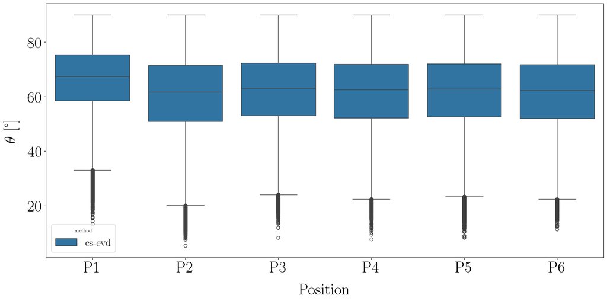

```python
# Boxplot at each position
sns.boxplot(data=df_theta, x="position", y="value", hue="method")
plt.ylabel(r"$\theta$ [°]")
plt.xlabel("Position")
```

### Distributions pour une position et tous les segments

```python
closest_recording
```

```
{'P1': 0.15, 'P2': 10.05, 'P3': 19.95, 'P4': 25.05, 'P5': 14.85, 'P6': 4.95}
```

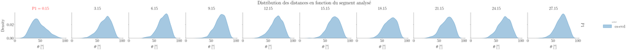

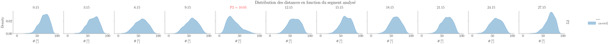

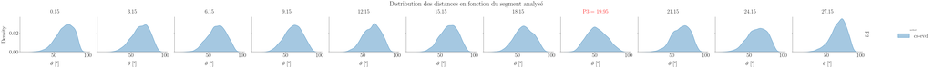

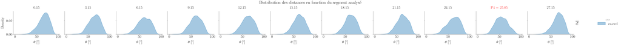

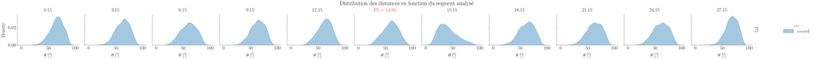

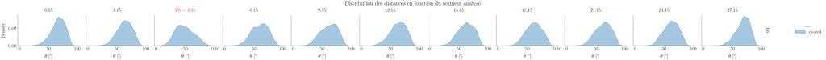

```python
# Subsample results for clarity
fsub = 10
for pos in df_theta["position"].unique():
    dist_subset = np.sort(np.append(dist[::fsub], closest_recording[pos]))
    df_theta_sub = df_theta[df_theta["window_tf"].isin(dist_subset)]
    df_theta_sub = df_theta_sub[df_theta_sub["position"] == pos]
    g = plot_all_distribution_panel(df_theta_sub, filter=False)

    g.figure.subplots_adjust(top=0.75, wspace=0.1)
    g.figure.suptitle(
            "Distribution des distances en fonction du segment analysé", fontsize=35
        )

    # Select axes corresponding to the position we are looking for
    i_ax_pos = list(dist_subset).index(closest_recording[pos])
    g.axes[0, i_ax_pos].set_title(f"{pos} = {dist_subset[i_ax_pos]}", color="r")
```

#### Commentaires

La forme des distributions varie fortement d'une position à localiser à l'autre. On ne peut pas clairement identifier une forme en loi de Gamma / Rayleigh (loi identifiable en statique) lorsque le vecteur de RTF est comparé au vecteur de la bonne position.

La variété importante de formes variables de distribution suggère d'utiliser une autre métrique que la moyenne empirique comme grandeur caractéristique.

# BILAN

Cette analyse sugère que la moyenne de la distribution n'est pas un choix optimal pour représenter la distribution sous-jacente des $\theta(k)$. L'option la plus simple pour améliorer le traitement simplement est de calculer l'espérance de la distribution :

$$ \overline{\theta} = \mathcal{E}[{\theta(k)}] = \sum_{k=1}^{K} p_k \theta(k) $$

où les probabilités $ p_k $ sont construites à partir de la distribution des $\theta(k)$. Par exemple :

$$ \hat{f} = \text{pdf} = \text{stats.gaussian\_kde}(\theta = (\theta(1), \dots, \theta(K))) $$

et on utilise $\hat{f}$ pour définir les $p_k$ :

$$ p_k = \hat{f}(\theta(k)) $$